# Actividad 1.8

Lucero Díaz

2026-10-08

```r
library(psych)
library(ggcorrplot)
library(performance)
library(GPArotation)
library(ppcor)
```

#### 1. Obtener la matriz de correlaciones y la matriz de valores p de significancia por pares. Interpreten los resultado en equipo.

```r
datos <- read.csv("C:/Users/ludio/Downloads/datoslago.csv")

M <- datos[, c("Tamano", "Temperatura", "Proteinas", "Oxigeno", "LnProteinas", "LnTamano")]

Corr <- corr.test(M, adjust = "none")

cat("Matriz de correlación (R) \n")
```

```
## Matriz de correlación (R)
```

```r
print(round(Corr$r, 4))
```

```
##              Tamano Temperatura Proteinas Oxigeno LnProteinas LnTamano
## Tamano       1.0000      0.2300    0.6311 -0.3435      0.8436   0.9743
## Temperatura  0.2300      1.0000   -0.2173  0.3384     -0.0789   0.2158
## Proteinas    0.6311     -0.2173    1.0000 -0.3685      0.7804   0.5710
## Oxigeno     -0.3435      0.3384   -0.3685  1.0000     -0.3790  -0.3057
## LnProteinas  0.8436     -0.0789    0.7804 -0.3790      1.0000   0.8582
## LnTamano     0.9743      0.2158    0.5710 -0.3057      0.8582   1.0000
```

```r
cat("\nMatriz de los p-values (P) \n")
```

```
##
## Matriz de los p-values (P)
```

```r
print(round(Corr$p, 4))
```

```
##             Tamano Temperatura Proteinas Oxigeno LnProteinas LnTamano
## Tamano      0.0000      0.0292    0.0000  0.0009      0.0000   0.0000
## Temperatura 0.0292      0.0000    0.0397  0.0011      0.4600   0.0411
## Proteinas   0.0000      0.0397    0.0000  0.0004      0.0000   0.0000
## Oxigeno     0.0009      0.0011    0.0004  0.0000      0.0002   0.0034
## LnProteinas 0.0000      0.4600    0.0000  0.0002      0.0000   0.0000
## LnTamano    0.0000      0.0411    0.0000  0.0034      0.0000   0.0000
```

Algunos de los insights más interesantes que sacamos de estas matrices son:

- Se observa un bloque fuertemente intercorrelacionado compuesto por Tamano, LnTamano, Proteinas y LnProteinas (donde la correlación mínima entre pares es $r > 0.57$ y sus p-values están todos por debajo de $p < 0.0001$). Estas variables están asociadas con la dimensión de productividad y escala limnológica.
- La variable Oxigeno presenta correlaciones negativas significativas con las variables de tamaño y proteínas ($r \approx -0.30 \text{ a } -0.38$) y positiva con Temperatura ($r = 0.3384, p = 0.0011$), reflejando el comportamiento del hábitat fisicoquímico.
- La única relación no estadísticamente significativa que muestra la matriz de p-values es la relación entre Temperatura y LnProteinas ($p = 0.4600$), lo cual también puede deducir considerado que su correlación es cercana a 0.

#### 2. Hacer una gráfica de la matriz de correlaciones. Hacer un comentario entre todos los del equipo de la gráfica. Interpretar también correlación parcial de los datos.

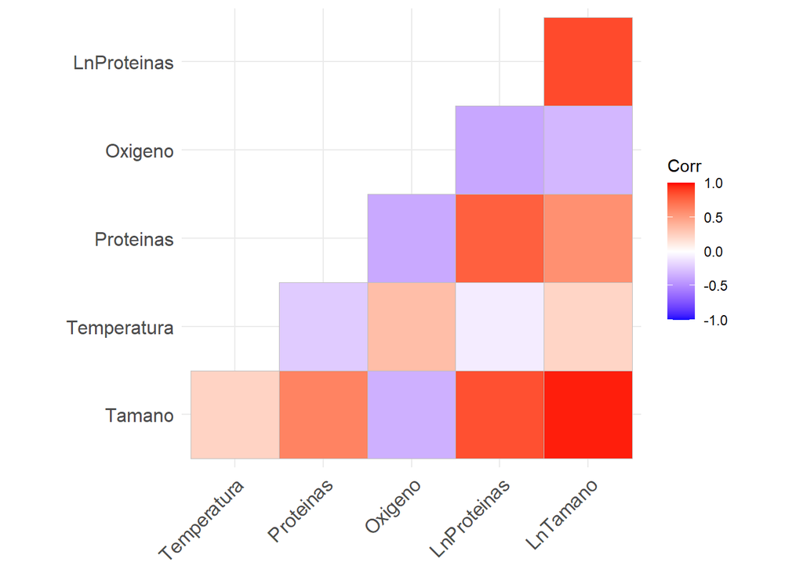

```r
matriz_corr <- ggcorrplot(Corr$r,type="lower")
corr_parcial <- corr.p(Corr$r, n = nrow(M), adjust = "none")
print(matriz_corr)
```

```r
print(corr_parcial)
```

```
## Call:corr.p(r = Corr$r, n = nrow(M), adjust = "none")
## Correlation matrix
##             Tamano Temperatura Proteinas Oxigeno LnProteinas LnTamano
## Tamano        1.00        0.23      0.63   -0.34        0.84     0.97
## Temperatura   0.23        1.00     -0.22    0.34       -0.08     0.22
## Proteinas     0.63       -0.22      1.00   -0.37        0.78     0.57
## Oxigeno      -0.34        0.34     -0.37    1.00       -0.38    -0.31
## LnProteinas   0.84       -0.08      0.78   -0.38        1.00     0.86
## LnTamano      0.97        0.22      0.57   -0.31        0.86     1.00
## Sample Size
## [1] 90
##             Tamano Temperatura Proteinas Oxigeno LnProteinas LnTamano
## Tamano        0.00        0.03      0.00       0        0.00     0.00
## Temperatura   0.03        0.00      0.04       0        0.46     0.04
## Proteinas     0.00        0.04      0.00       0        0.00     0.00
## Oxigeno       0.00        0.00      0.00       0        0.00     0.00
## LnProteinas   0.00        0.46      0.00       0        0.00     0.00
## LnTamano      0.00        0.04      0.00       0        0.00     0.00
##
##  To see confidence intervals of the correlations, print with the short=FALSE option
```

En la matriz se pueden observar dos núcleos de covarianza: un grupo de bloques con colores cálidos, representando alta correlación positiva, formado por Tamano, LnTamano, Proteinas y LnProteinas; y otro grupo de bloques con tonos fríos/neutros, relacionados con el resto de variables (Oxigeno, Temperatura).

```r
resultado <- pcor(M)
resultado$estimate  # Matriz de coeficientes de correlación parcial
```

```
##                 Tamano Temperatura   Proteinas     Oxigeno LnProteinas
## Tamano       1.0000000   0.3139977  0.51912134 -0.27685105 -0.23568920
## Temperatura  0.3139977   1.0000000 -0.21211546  0.42191470 -0.24685528
## Proteinas    0.5191213  -0.2121155  1.00000000  0.07128965  0.62525169
## Oxigeno     -0.2768511   0.4219147  0.07128965  1.00000000 -0.02452851
## LnProteinas -0.2356892  -0.2468553  0.62525169 -0.02452851  1.00000000
## LnTamano     0.9038003  -0.0623774 -0.55051599  0.16877163  0.55349041
##               LnTamano
## Tamano       0.9038003
## Temperatura -0.0623774
## Proteinas   -0.5505160
## Oxigeno      0.1687716
## LnProteinas  0.5534904
## LnTamano     1.0000000
```

```r
resultado$p.value   # Matriz de p-values
```

```
##                   Tamano  Temperatura    Proteinas      Oxigeno  LnProteinas
## Tamano      0.000000e+00 3.238614e-03 3.039797e-07 9.865982e-03 2.891940e-02
## Temperatura 3.238614e-03 0.000000e+00 4.991799e-02 5.209361e-05 2.194453e-02
## Proteinas   3.039797e-07 4.991799e-02 0.000000e+00 5.142273e-01 1.232079e-10
## Oxigeno     9.865982e-03 5.209361e-05 5.142273e-01 0.000000e+00 8.226225e-01
## LnProteinas 2.891940e-02 2.194453e-02 1.232079e-10 8.226225e-01 0.000000e+00
## LnTamano    1.044019e-32 5.683009e-01 3.988415e-08 1.203307e-01 3.254407e-08
##                 LnTamano
## Tamano      1.044019e-32
## Temperatura 5.683009e-01
## Proteinas   3.988415e-08
## Oxigeno     1.203307e-01
## LnProteinas 3.254407e-08
## LnTamano    0.000000e+00
```

Al calcular la correlación parcial, se observa una disminución drástica entre la mayoría de los valores absolutos de los coeficientes de correlacion entre parejas. Esto se debe a la redundancia de información (colinealidad) entre las variables directas y sus transformaciones logarítmicas. Tamano y LnTamano se explican casi en su totalidad mutuamente, reduciendo la covarianza residual explicable por el resto del sistema. En la matriz de p-values también se observa una mayor cantidad de correlaciones entre parejas donde no se rechaza la hipótesis nula ($p > 0.05$), implicando que no son estadísticamente significativas.